# NMF_demo

2023-09-18

```
#BiocManager::install('Biobase')
#install.packages('NMF') ## install.extras('NMF')
#install.packages("ggsci")
#BiocManager::install('limma')
```

# 0. test time consuming

## (1)intro

我们为什么要用NMF呢？一个很重要的原因是NMF的因子可解释性更强，每个因子贡献度最大的基因基本代表了某种或某个状态细胞的表达模式，相比差异分析得到marker基因更有代表性。

NMF包通过nmf()函数实现矩阵分解，它的用法及重要参数如下： `> nmf(x, rank, method, seed, nrun, ...)`

```
x：待分解非负矩阵，数据格式可以是matrix，data.frame， ExpressionSet
rank：分解的基数量，对于单细胞数据，可以设置为期望的细胞类型数量或表达模式数量
method：因式分解的常用方法，这里介绍三种常用的
1、基于KL 散度进行度量目标函数的多重迭代梯度下降算法——brunet(默认算法)
2、基于欧几里得距离度量目标函数的多重迭代梯度下降算法——lee
3、交替最小二乘法(Alternating Least Squares(ALS))——snmf/r
seed：因式分解的初始化种子
nrun：运行次数
```

因为NMF一般是从随机数开始，通过迭代算法收敛误差的方法求出最优W和H矩阵，所以seed不同最后的结果也不同。为了减少seed的影响求得最优解，常规的办法是通过nrun参数设置运行100-200次矩阵分解选取最优值，也可以使用特殊的算法选择一个最佳的seed（设置seed=‘nndsvd’或seed=’ica’），这样运行一次也能得到最优解。

## (2)耗时

```r
library(Biobase)
library(NMF)
```

```r
library(ggplot2)
library(dplyr) #tidyverse
library(patchwork)

## 参数测试
data("esGolub")
#str(esGolub)

if(0){
  #esGolub <- esGolub[1:500,]
  t1 <- nmf(esGolub, 3, method = "brunet", seed = 219)
  runtime(t1)   # elapsed: 1.358

  t2 <- nmf(esGolub, 3, method = "lee", seed = 219)
  runtime(t2)   # elapsed: 1.884

  t3 <- nmf(esGolub, 3, method = "snmf/r", seed = 219)
  runtime(t3)   # elapsed: 1.774

  t4 <- nmf(esGolub, 3, method = "brunet", seed = 'nndsvd')
  runtime(t4)   # elapsed: 3.058

  t5 <- nmf(esGolub, 3, method = "brunet", nrun = 100)
  runtime(t5)   # elapsed: 2.089

  t6 <- nmf(esGolub, 3, method = "nsNMF", nrun = 100)
  runtime(t6)   # elapsed: 2.207
}
```

# 1. pbmc3k

```r
library(Seurat)
```

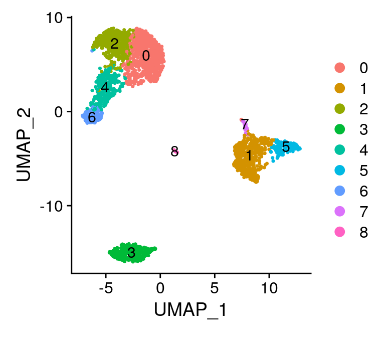

```r
scObj = readRDS("../result/data/pbmc_tutorial.rds")
DimPlot(scObj, label = T)
```

```r
if(0){
  library(NMF)

  ##(1) 创建seurat对象----
  pbmc <- Read10X_h5("pbmc.h5")
  pbmc <- CreateSeuratObject(pbmc, project = "pbmc", min.cells = 3, min.features = 500)
  pbmc$percent.mt <- PercentageFeatureSet(pbmc, pattern = "^MT-")
  pbmc <- subset(pbmc, percent.mt<20)
  pbmc <- NormalizeData(pbmc) %>% FindVariableFeatures() %>% ScaleData(do.center = F)

  ##(2) 使用pca的分解结果降维聚类----
  pbmc <- RunPCA(pbmc)
  set.seed(219)
  pbmc.pca <- RunUMAP(pbmc, dims = 1:15) %>% FindNeighbors(dims = 1:15) %>% FindClusters()

  ## 结果可视化
  DimPlot(pbmc.pca, label = T) + ggsci::scale_color_igv()
  #ggsave("pbmc_pca.png", p, width = 9, height = 6)

  p <- FeaturePlot(pbmc.pca, features = c('CD3D', 'CD3E', 'MS4A1', 'CD79A', 'GNLY', 'NKG7', 'CD14',
                                          'FCGR3A', 'PPBP', 'FCER1A', 'CD4', 'CD8A'), ncol = 4)
  p
  #ggsave("pbmc_pca_markers.png", p, width = 12, height = 8)
}
```